[figure not shown]

# Gradient Boosting and GridSearch

## The Data

[figure not shown]

### Mushroom Hunting: Edible or Poisonous?

Data Source: https://archive.ics.uci.edu/ml/datasets/Mushroom

This data set includes descriptions of hypothetical samples corresponding to 23 species of gilled mushrooms in the Agaricus and Lepiota Family (pp. 500-525). Each species is identified as definitely edible, definitely poisonous, or of unknown edibility and not recommended. This latter class was combined with the poisonous one. The Guide clearly states that there is no simple rule for determining the edibility of a mushroom; no rule like ``leaflets three, let it be'' for Poisonous Oak and Ivy.

Attribute Information:

1. cap-shape: bell=b,conical=c,convex=x,flat=f, knobbed=k,sunken=s
2. cap-surface: fibrous=f,grooves=g,scaly=y,smooth=s
3. cap-color: brown=n,buff=b,cinnamon=c,gray=g,green=r, pink=p,purple=u,red=e,white=w,yellow=y
4. bruises?: bruises=t,no=f
5. odor: almond=a,anise=l,creosote=c,fishy=y,foul=f, musty=m,none=n,pungent=p,spicy=s
6. gill-attachment: attached=a,descending=d,free=f,notched=n
7. gill-spacing: close=c,crowded=w,distant=d
8. gill-size: broad=b,narrow=n
9. gill-color: black=k,brown=n,buff=b,chocolate=h,gray=g, green=r,orange=o,pink=p,purple=u,red=e, white=w,yellow=y
10. stalk-shape: enlarging=e,tapering=t
11. stalk-root: bulbous=b,club=c,cup=u,equal=e, rhizomorphs=z,rooted=r,missing=?
12. stalk-surface-above-ring: fibrous=f,scaly=y,silky=k,smooth=s
13. stalk-surface-below-ring: fibrous=f,scaly=y,silky=k,smooth=s
14. stalk-color-above-ring: brown=n,buff=b,cinnamon=c,gray=g,orange=o, pink=p,red=e,white=w,yellow=y
15. stalk-color-below-ring: brown=n,buff=b,cinnamon=c,gray=g,orange=o, pink=p,red=e,white=w,yellow=y
16. veil-type: partial=p,universal=u
17. veil-color: brown=n,orange=o,white=w,yellow=y
18. ring-number: none=n,one=o,two=t
19. ring-type: cobwebby=c,evanescent=e,flaring=f,large=l, none=n,pendant=p,sheathing=s,zone=z
20. spore-print-color: black=k,brown=n,buff=b,chocolate=h,green=r, orange=o,purple=u,white=w,yellow=y
21. population: abundant=a,clustered=c,numerous=n, scattered=s,several=v,solitary=y
22. habitat: grasses=g,leaves=l,meadows=m,paths=p, urban=u,waste=w,woods=d

## Imports

```python
import numpy as np
import pandas as pd

import matplotlib.pyplot as plt
import seaborn as sns
```

```python
df = pd.read_csv("../DATA/mushrooms.csv")
```

```python
df.head()
```

|  | class | cap-shape | cap-surface | cap-color | bruises | odor | gill-attachment | gill-spacing | gill-size | gill-color | ... | stalk-surface-below-ring | stalk-color-above-ring | stalk-color-below-ring | veil-type | veil-color | ring-number | ring-type | spore-print-color | population | habitat |
| --- | --- | --- | --- | --- | --- | --- | --- | --- | --- | --- | --- | --- | --- | --- | --- | --- | --- | --- | --- | --- | --- |
| 0 | p | x | s | n | t | p | f | c | n | k | ... | s | w | w | p | w | o | p | k | s | u |
| 1 | e | x | s | y | t | a | f | c | b | k | ... | s | w | w | p | w | o | p | n | n | g |
| 2 | e | b | s | w | t | l | f | c | b | n | ... | s | w | w | p | w | o | p | n | n | m |
| 3 | p | x | y | w | t | p | f | c | n | n | ... | s | w | w | p | w | o | p | k | s | u |
| 4 | e | x | s | g | f | n | f | w | b | k | ... | s | w | w | p | w | o | e | n | a | g |

5 rows × 23 columns

## Data Prep

```python
X = df.drop('class',axis=1)
```

```python
y = df['class']
```

```python
X = pd.get_dummies(X,drop_first=True)
```

```python
X.head()
```

|  | cap-shape_c | cap-shape_f | cap-shape_k | cap-shape_s | cap-shape_x | cap-surface_g | cap-surface_s | cap-surface_y | cap-color_c | cap-color_e | ... | population_n | population_s | population_v | population_y | habitat_g | habitat_l | habitat_m | habitat_p | habitat_u | habitat_w |
| --- | --- | --- | --- | --- | --- | --- | --- | --- | --- | --- | --- | --- | --- | --- | --- | --- | --- | --- | --- | --- | --- |
| 0 | 0 | 0 | 0 | 0 | 1 | 0 | 1 | 0 | 0 | 0 | ... | 0 | 1 | 0 | 0 | 0 | 0 | 0 | 0 | 1 | 0 |
| 1 | 0 | 0 | 0 | 0 | 1 | 0 | 1 | 0 | 0 | 0 | ... | 1 | 0 | 0 | 0 | 1 | 0 | 0 | 0 | 0 | 0 |
| 2 | 0 | 0 | 0 | 0 | 0 | 0 | 1 | 0 | 0 | 0 | ... | 1 | 0 | 0 | 0 | 0 | 0 | 1 | 0 | 0 | 0 |
| 3 | 0 | 0 | 0 | 0 | 1 | 0 | 0 | 1 | 0 | 0 | ... | 0 | 1 | 0 | 0 | 0 | 0 | 0 | 0 | 1 | 0 |
| 4 | 0 | 0 | 0 | 0 | 1 | 0 | 1 | 0 | 0 | 0 | ... | 0 | 0 | 0 | 0 | 1 | 0 | 0 | 0 | 0 | 0 |

5 rows × 95 columns

```python
y.head()
```

```
0    p
1    e
2    e
3    p
4    e
Name: class, dtype: object
```

## Train Test Split

```python
from sklearn.model_selection import train_test_split
```

```python
X_train, X_test, y_train, y_test = train_test_split(X, y, test_size=0.15, random_state=101)
```

## Gradient Boosting and Grid Search with CV

```python
from sklearn.ensemble import GradientBoostingClassifier
```

```python
help(GradientBoostingClassifier)
```

[output not shown]

[output cut: 432 more lines]

[output not shown]

```python
from sklearn.model_selection import GridSearchCV
```

```python
param_grid = {"n_estimators":[1,5,10,20,40,100],'max_depth':[3,4,5,6]}
```

```python
gb_model = GradientBoostingClassifier()
```

```python
grid = GridSearchCV(gb_model,param_grid)
```

### Fit to Training Data with CV Search

```python
grid.fit(X_train,y_train)
```

```
GridSearchCV(estimator=GradientBoostingClassifier(),
             param_grid={'max_depth': [3, 4, 5, 6],
                         'n_estimators': [1, 5, 10, 20, 40, 100]})
```

```python
grid.best_params_
```

```
{'max_depth': 3, 'n_estimators': 100}
```

## Performance

```python
from sklearn.metrics import classification_report,plot_confusion_matrix,accuracy_score
```

```python
predictions = grid.predict(X_test)
```

```python
predictions
```

```
array(['p', 'e', 'p', ..., 'p', 'p', 'e'], dtype=object)
```

```python
print(classification_report(y_test,predictions))
```

```
              precision    recall  f1-score   support

           e       1.00      1.00      1.00       655
           p       1.00      1.00      1.00       564

    accuracy                           1.00      1219
   macro avg       1.00      1.00      1.00      1219
weighted avg       1.00      1.00      1.00      1219
```

```python
grid.best_estimator_.feature_importances_
```

```
array([2.91150176e-04, 1.55427847e-17, 2.67658844e-21, 0.00000000e+00,
       1.11459235e-16, 1.05030313e-03, 3.26837862e-18, 9.23288948e-17,
       3.33934930e-18, 0.00000000e+00, 1.27133255e-17, 0.00000000e+00,
       3.56629935e-17, 2.46527883e-21, 0.00000000e+00, 5.60405971e-07,
       2.31055039e-03, 5.13955090e-02, 1.84253604e-04, 1.40371481e-02,
       1.82499853e-02, 3.13472494e-03, 6.14744334e-01, 9.20844491e-04,
       0.00000000e+00, 0.00000000e+00, 5.26020065e-19, 1.25278108e-02,
       1.16509070e-02, 0.00000000e+00, 4.86322971e-17, 0.00000000e+00,
       1.08107877e-17, 1.10350576e-21, 0.00000000e+00, 3.66548515e-17,
       2.07693543e-16, 0.00000000e+00, 1.80938787e-17, 0.00000000e+00,
       4.39922283e-04, 0.00000000e+00, 1.35977416e-01, 7.71855052e-03,
       3.23882633e-02, 4.64723214e-04, 1.49599812e-03, 4.95063766e-06,
       1.83319493e-05, 1.70638552e-06, 3.38601933e-02, 2.07732168e-03,
       0.00000000e+00, 0.00000000e+00, 6.80156959e-04, 0.00000000e+00,
       0.00000000e+00, 5.74694069e-04, 0.00000000e+00, 1.84524355e-04,
       0.00000000e+00, 0.00000000e+00, 5.33104127e-05, 0.00000000e+00,
       0.00000000e+00, 0.00000000e+00, 3.02342639e-03, 0.00000000e+00,
       1.35380870e-07, 7.74443653e-05, 2.62871992e-03, 0.00000000e+00,
       7.08716926e-05, 0.00000000e+00, 1.32788040e-03, 1.83494013e-03,
       7.34476580e-03, 2.14240381e-04, 2.08941481e-04, 0.00000000e+00,
       3.04953583e-02, 4.10000880e-03, 4.86768755e-04, 0.00000000e+00,
       1.17434515e-03, 0.00000000e+00, 7.67619495e-08, 1.34881889e-05,
       5.50395653e-04, 1.82220979e-16, 0.00000000e+00, 9.07373812e-17,
       0.00000000e+00, 1.00485103e-05, 0.00000000e+00])
```

```python
feat_import = grid.best_estimator_.feature_importances_
```

```python
imp_feats = pd.DataFrame(index=X.columns,data=feat_import,columns=['Importance'])
```

```python
imp_feats
```

|  | Importance |
| --- | --- |
| cap-shape_c | 2.911502e-04 |
| cap-shape_f | 1.554278e-17 |
| cap-shape_k | 2.676588e-21 |
| cap-shape_s | 0.000000e+00 |
| cap-shape_x | 1.114592e-16 |
| ... | ... |
| habitat_l | 0.000000e+00 |
| habitat_m | 9.073738e-17 |
| habitat_p | 0.000000e+00 |
| habitat_u | 1.004851e-05 |
| habitat_w | 0.000000e+00 |

95 rows × 1 columns

```python
imp_feats.sort_values("Importance",ascending=False)
```

|  | Importance |
| --- | --- |
| odor_n | 0.614744 |
| stalk-root_c | 0.135977 |
| bruises_t | 0.051396 |
| stalk-surface-below-ring_y | 0.033860 |
| stalk-root_r | 0.032388 |
| ... | ... |
| veil-color_o | 0.000000 |
| gill-color_y | 0.000000 |
| odor_y | 0.000000 |
| odor_s | 0.000000 |
| habitat_w | 0.000000 |

95 rows × 1 columns

```python
imp_feats.describe().transpose()
```

|  | count | mean | std | min | 25% | 50% | 75% | max |
| --- | --- | --- | --- | --- | --- | --- | --- | --- |
| Importance | 95.0 | 0.010526 | 0.06463 | 0.0 | 0.0 | 1.822210e-16 | 0.000801 | 0.614744 |

```python
imp_feats = imp_feats[imp_feats['Importance'] > 0.000527]
```

```python
imp_feats.sort_values('Importance')
```

|  | Importance |
| --- | --- |
| population_y | 0.000550 |
| stalk-color-above-ring_w | 0.000575 |
| stalk-color-above-ring_n | 0.000680 |
| odor_p | 0.000921 |
| cap-surface_g | 0.001050 |
| population_c | 0.001174 |
| ring-type_n | 0.001328 |
| stalk-surface-above-ring_s | 0.001496 |
| ring-type_p | 0.001835 |
| stalk-color-above-ring_c | 0.002077 |
| cap-color_y | 0.002311 |
| ring-number_o | 0.002629 |
| stalk-color-below-ring_y | 0.003023 |
| odor_m | 0.003135 |
| spore-print-color_u | 0.004100 |
| spore-print-color_h | 0.007345 |
| stalk-root_e | 0.007719 |
| gill-size_n | 0.011651 |
| gill-spacing_w | 0.012528 |
| odor_f | 0.014037 |
| odor_l | 0.018250 |
| spore-print-color_r | 0.030495 |
| stalk-root_r | 0.032388 |
| stalk-surface-below-ring_y | 0.033860 |
| bruises_t | 0.051396 |
| stalk-root_c | 0.135977 |
| odor_n | 0.614744 |

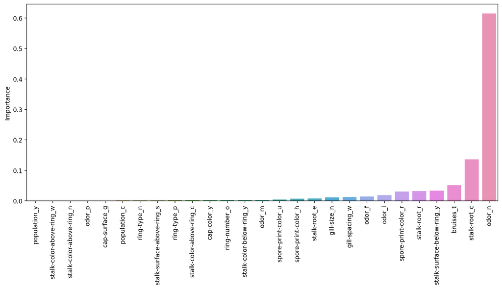

```python
plt.figure(figsize=(14,6),dpi=200)
sns.barplot(data=imp_feats.sort_values('Importance'),x=imp_feats.sort_values('Importance').index,y='Importance')
plt.xticks(rotation=90);
```